# 🎬 Movie Recommendation system

**Fast, Scalable, and Interpretable Movie Recommendation System using Neo4j + HNSW (Approximate Nearest Neighbors) on the Movielens dataset**

## 1-Overview

This project aims to build a **film recommendation system** based on the **MovieLens** dataset. To achieve our goal we use a method called `Approximate Nearest Neighbors(ANN)`

The **ANN Movie Recommender** is a recommendation engine that combines **content-based**, **collaborative**, and **hybrid filtering** approaches using **Approximate Nearest Neighbor (ANN)** search with **HNSW (Hierarchical Navigable Small World)** graphs.

Our application runs as an interactive **Streamlit app**, powered by **Neo4j** for data storage and **HNSWlib** for fast vector similarity search.  
This framework makes it easy to explore, visualize, and understand how movie recommendations are computed based on genre similarity, user ratings, and hybrid weighting.

## 2-Key Features

- **Content-Based Filtering** → Recommends movies with similar *features or genres*.
- **Collaborative Filtering** → Suggests movies liked by *similar users* (based on ratings).
- **Hybrid Filtering (Mixed)** → Merges both models proportionally using weights $\alpha$ and $\beta$.
- **Interactive Evaluation Metrics**: Balance Score, Content Quality, Personalization, Novelty, and Serendipity.
- **Neo4j Integration** for graph-based querying of users, movies, and relationships.

## 3-Architecture

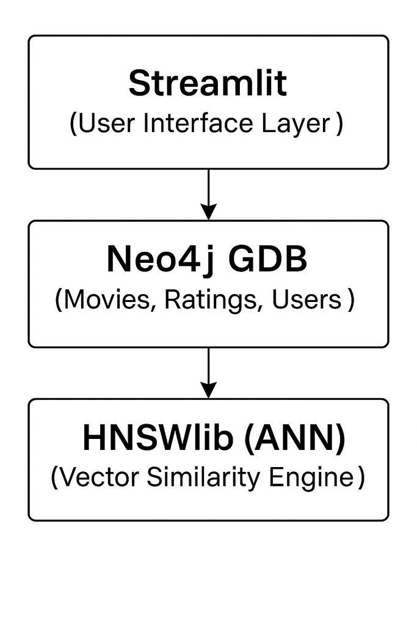

## 4-Recommendation Methods

### Content-Based (Cosine Similarity)

Each movie is represented as a vector of features or genres.  
Similarity is computed as:

$$\cos(\mathbf{x}, \mathbf{y}) = \frac{\mathbf{x} \cdot
\mathbf{y}}{\|\mathbf{x}\| \|\mathbf{y}\|}$$

### Collaborative Filtering (Item-Item ANN)

Each item vector is constructed from user ratings:

$$v_i[u] = r(u,i) - \bar{r_i}$$

User profile:

$$\mathbf{p_u} = \frac{1}{|I_u|} \sum_{i \in I_u, r(u,i) > 4} v_i$$

### Hybrid (Mixed)

A combined recommendation list using weighted sampling:

$$s(m) = \alpha \cdot s_{content}(m) + \beta \cdot s_{cf}(m)$$

## 5-Evaluation Metrics

| Metric | Description |
| --- | --- |
| **Balance Score** | Measures equilibrium between content similarity and personalization. |
| **Content Quality** | How close results are to the anchor movie (semantic similarity). |
| **Personalization** | How well results match the user’s high-rated preferences . |
| **Novelty** | Share of new or unseen movies for the user. |
| **Serendipity** | Mix of familiar yet surprising recommendations. |

## 6-Prerequisites

Before running the app, ensure you have: 1. **Neo4j Database** (Desktop, AuraDB, or Docker).

2. **MovieLens Dataset** (movies.csv & ratings.csv).
3. **Python 3.8+** installed.
4. Required packages installed:

   ```bash
   pip install streamlit neo4j hnswlib pandas numpy
   ```

5. **Valid Neo4j credentials** (`username`, `password`, `bolt://localhost:7687`).
6. Access Neo4j Browser locally at http://localhost:7474/.

If you experience issues setting up Neo4j, refer to the official [Neo4j Docs](https://neo4j.com/docs/) or the [GitHub installation guide](https://github.com/).

## 7-Run the App

1. Clone the repository:

   ```bash
   git clone https://github.com/fathnelle4/Movie-Recommendation-System.git
   cd Movie-Recommendation-System
   ```

2. Launch the app:

   ```bash
   streamlit run Movie-Recommendation-System.py
   ```

3. Connect to your Neo4j database in the sidebar.
4. Choose a recommendation mode (Content, Collaborative, or Hybrid).
5. Explore metrics and visualize recommendation quality!
6. Browse through descriptive analyse

## 📚 References

- Malkov, Y. & Yashunin, D. (2018). *Efficient and Robust Approximate Nearest Neighbor Search Using HNSW*. [arXiv:1603.09320](https://arxiv.org/abs/1603.09320)
- [Movielens Dataset](https://grouplens.org/datasets/movielens/)
- [Cosine Similarity - Medium](https://naomy-gomes.medium.com/the-cosine-similarity-and-its-use-in-recommendation-systems-cb2ebd811ce1)
- [Content-Based Recommender - GeeksforGeeks](https://www.geeksforgeeks.org/machine-learning/ml-content-based-recommender-system/)
- [Approximate Nearest Neighbor Search - GeeksforGeeks](https://www.geeksforgeeks.org/machine-learning/approximate-nearest-neighbor-ann-search/)
- [Collaborative Filtering - GeeksforGeeks](https://www.geeksforgeeks.org/collaborative-filtering-in-recommendation-systems/)
- [Naomy Gomes - Cosine Similarity and its use in Recommender Systems](https://naomy-gomes.medium.com/the-cosine-similarity-and-its-use-in-recommendation-systems-cb2ebd811ce1)
- [Neo4j Graph Data Science Documentation](https://neo4j.com/docs/graph-data-science/current/)
- [FAISS - Facebook AI Similarity Search](https://github.com/facebookresearch/faiss)
- [Annoy - Spotify Approximate Nearest Neighbors](https://github.com/spotify/annoy)
- [Voyager - Spotify HNSW-based ANN](https://github.com/spotify/voyager)

## 👥 Authors

- **Glorie Metsa Wowo** - [LinkedIn](https://www.linkedin.com/in/glorie-wowo-data-science-edtech)
- **Fathnelle Mehouelley** - [LinkedIn](https://www.linkedin.com/in/fathnelle-mehouelley/)

© 2025 ANN Movie Recommender - Powered by Neo4j, HNSWlib, and Streamlit